# BR CoopScore

2025-06-06

```r
library(tidyverse)
```

Open files from Castro database (.dta)

```r
relationdb <- haven::read_dta(here::here("dbs","Castro", "ENB_relationships.dta"))
```

# 1 Cooperation index

Generate the cooperation index.

First, we filter statements by Brazil (sender, C1) or about Brazil (target, C2)

```r
BR_statements <- relationdb %>% filter(Country1 == "Brazil" | Country2 == "Brazil")
```

Calculating scores for agreement with G77 countries How much does BRA agree to G77 countries? (0 = not g77, 1= g77 member, 2= g77 itself)

```r
BR_statements %>% filter(Country1 == "Brazil") %>%
  mutate(cooperation = if_else(cooperation == 0, -1, 1)) %>%
  group_by(G77_target, year) %>%
  summarise(coop_score = sum(cooperation), weighted_score = sum(relation))
```

| G77_target | year | coop_score | weighted_score |
| --- | --- | --- | --- |
| 0 | 1995 | 23 | 202 |
| 0 | 1996 | 13 | 50 |
| 0 | 1997 | 0 | 50 |
| 0 | 1998 | 1 | 34 |
| 0 | 1999 | 17 | 116 |
| 0 | 2000 | 4 | 222 |
| 0 | 2001 | -3 | 48 |
| 0 | 2002 | -1 | 46 |
| 0 | 2003 | 9 | 45 |
| 0 | 2004 | -6 | 123 |

[output cut: 42 more lines]

We will calculate the cooperation index with a general function that takes country grouping as an argument.

```r
calculate_coop <- function(grouping, country = "Brazil",
                           statementsdb = relationdb, aggregateby = "year"){

  sender = paste0(grouping, "_sender")
  target = paste0(grouping, "_target")
  countryid_send = statementsdb[statementsdb$Country1 == country, "country1"] %>%
    unique %>% haven::zap_labels() %>% pull(country1)
  countryid_targ = statementsdb[statementsdb$Country2 == country, "country2"] %>%
    unique %>% haven::zap_label() %>% pull(country2)


  #Count statements sent or targeting the country
  country_sentstatements <- statementsdb %>% filter(country1 == countryid_send) %>%
    group_by(!!rlang::parse_quo(aggregateby, #parse_quo faz string -> expressao
                                env = rlang::caller_env())) %>%  summarise(n_send = n())
    # group_by(aggregateby) %>%  summarise(n_send = n())
  country_tgtstatements <- statementsdb %>% filter(country2 == countryid_targ) %>%
    group_by(!!rlang::parse_quo(aggregateby, #parse_quo faz string -> expressao
                                env = rlang::caller_env())) %>%  summarise(n_targ = n())
    # group_by(aggregateby) %>%  summarise(n_targ = n())
  country_totalstatements <- left_join(country_sentstatements, country_tgtstatements) %>%
    mutate(state_total = n_send + n_targ)


  statementsdb %>%
    #filter statements
    filter(Country1 == country | Country2 == country) %>%
    # fuse sender and target
    # (include both directions of relations to grouping)
    mutate( {{grouping}} :=
              # chaves e := é pra variável ser mutável cf arg
              case_when(
                # 2 = grouping spokesman
                !!rlang::parse_quo(sender, #parse_quo faz string -> expressao
                                   env = rlang::caller_env()) == 2 |
                  !!rlang::parse_quo(target,
                                     env = rlang::caller_env()) == 2 ~ 2,
                # 1 = country in grouping
                # since analyzed country can be in grouping, disconsider
                # when send/targ is the country analysed
                !!rlang::parse_quo(sender, env = rlang::caller_env()) == 1 &
                  country1 != countryid_send | !!rlang::parse_quo(target,
                                                                  env = rlang::caller_env()) == 1 &
                  country2 != countryid_targ ~ 1,

                # 0 = not in grouping
                !!rlang::parse_quo(sender, env = rlang::caller_env()) == 0 &
                  country1 != countryid_send | !!rlang::parse_quo(target,
                                                                  env = rlang::caller_env()) == 0 &
                  country2 != countryid_targ ~ 0
              )
    ) %>%
    #summarise scores
    group_by(!!rlang::parse_quo(grouping, env = rlang::caller_env()),
             !!rlang::parse_quo(aggregateby, env = rlang::caller_env())
             #aggregateby
             ) %>%
    summarise(coop_score = sum(cooperation),
              weighted_score = sum(relation)) %>%
    pivot_wider(names_from = !!rlang::parse_quo(grouping, env = rlang::caller_env()),
                 values_from = c(coop_score, weighted_score)) %>%
    replace(is.na(.), 0) %>% #NA coded as 0
    left_join(country_totalstatements) %>% # include data on n of statements
    mutate(country = {{country}},
           grouping = {{grouping}}
           ) # %>%
    # mutate(coop_score = sum(coop_score_2, coop_score_1, - coop_score_0, na.rm = T),
    #        # weighted_score = sum(weighted_score_2, weighted_score_1, - weighted_score_0,
    #        #                   na.rm = T)
    #        ) %>%
    # # relativize_scores
    # left_join(country_totalstatements) %>%
    # mutate(coop_avg = coop_score/state_total,
    #        # weighted_score_avg = weighted_score/state_total
    #        ) %>%
    # mutate(grouping = {{grouping}})

}
```

We then use the *finish_coop_scores()* function to calculate two versions for the index. The first uses a simplified version of Castro’s data, which uses unweighted interactions (relation is binary - cooperation or conflict). The second uses Castro’s weight scheme for relations, which differentiates the intensity of cooperation/conflict in each interaction.

```r
finish_coop_scores <- function(coopdb){
  column_checker <- tibble(coop_score_0=numeric(),
                           coop_score_1=numeric(),
                           coop_score_2=numeric(),
                           weighted_score_2=numeric(),
                           weighted_score_1=numeric(),
                           weighted_score_0=numeric()
  )

  coopdb %>% left_join(column_checker) %>%
  mutate(coop_score = coop_score_2 + coop_score_1 - coop_score_0,
         weighted_score = weighted_score_2 + weighted_score_1 - weighted_score_0
         ) %>%
  # relativize_scores
  mutate(coop_avg = coop_score/state_total,
         weighted_score_avg = weighted_score/state_total
         )
}
```

Now we can calculate cooperation scores for various groupings

```r
BReu <- calculate_coop("EU", "Brazil", relationdb) %>% finish_coop_scores()
```

```
## argument.
## weighted_score_0, weighted_score_1, weighted_score_2)`
```

```r
BRaosis <- calculate_coop("AOSIS", "Brazil", relationdb) %>% finish_coop_scores()
```

```
## weighted_score_0, weighted_score_1, weighted_score_2)`
```

```r
BRg77 <- calculate_coop("G77", "Brazil", relationdb) %>% finish_coop_scores()
```

```
## argument.
## weighted_score_0, weighted_score_1, weighted_score_2)`
```

```r
BRbasic <- calculate_coop( "BASIC", "Brazil", relationdb) %>% finish_coop_scores()
```

```
## weighted_score_0, weighted_score_1, weighted_score_2)`
```

## 1.1 Figures for disaggregated cooperation scores

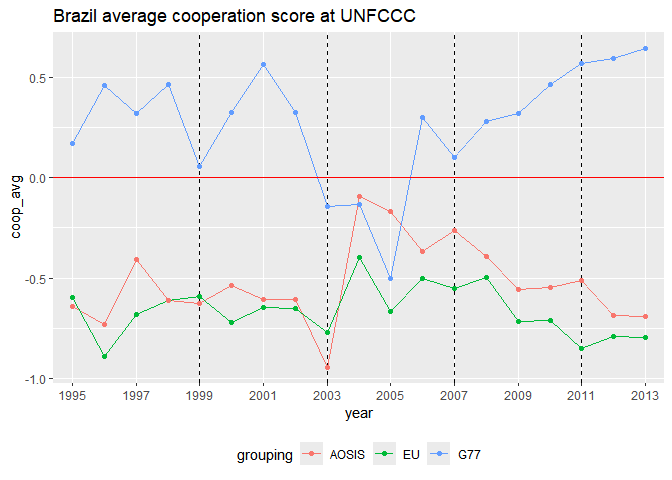

```r
bind_rows(BReu, BRg77, BRaosis) %>% ggplot(aes(x=year, color = grouping)) +
  geom_line(aes(y = coop_avg)) + geom_hline(yintercept = 0, color = "red") +
  geom_vline(xintercept = c(1999, 2003, 2007, 2011), linetype = 'dashed') +
  geom_point(aes(y = coop_avg)) +
  scale_x_discrete(limits = c(1995, 1997, 1999, 2001,
                              2003, 2005, 2007, 2009, 2011, 2013)) +
  ggtitle("Brazil average cooperation score at UNFCCC") +
  theme(legend.position = 'bottom')
```

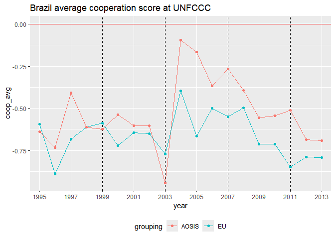

```r
bind_rows(BReu, BRaosis) %>% ggplot(aes(x=year, color = grouping)) +
  geom_line(aes(y = coop_avg)) + geom_hline(yintercept = 0, color = "red") +
  geom_vline(xintercept = c(1999, 2003, 2007, 2011), linetype = 'dashed') +
  geom_point(aes(y = coop_avg)) +
  scale_x_discrete(limits = c(1995, 1997, 1999, 2001,
                              2003, 2005, 2007, 2009, 2011, 2013)) +
  ggtitle("Brazil average cooperation score at UNFCCC") +
  theme(legend.position = 'bottom')
```

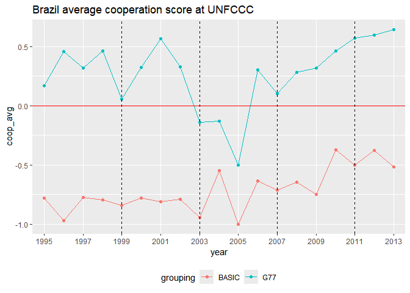

```r
bind_rows(BRg77, BRbasic) %>% ggplot(aes(x=year, color = grouping)) +
  geom_line(aes(y = coop_avg)) + geom_hline(yintercept = 0, color = "red") +
  geom_point(aes(y = coop_avg)) +
  geom_vline(xintercept = c(1999, 2003, 2007, 2011), linetype = 'dashed') +
  scale_x_discrete(limits = c(1995, 1997, 1999, 2001,
                              2003, 2005, 2007, 2009, 2011, 2013)) +
  ggtitle("Brazil average cooperation score at UNFCCC") +
  theme(legend.position = 'bottom')
```

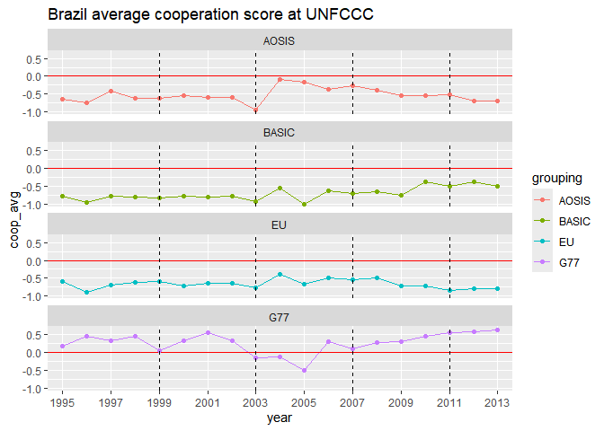

```r
bind_rows(BReu, BRg77, BRaosis, BRbasic) %>% ggplot(aes(x=year, color = grouping)) +
  geom_line(aes(y = coop_avg)) + geom_hline(yintercept = 0, color = "red") +
  geom_point(aes(y = coop_avg)) +
  geom_vline(xintercept = c(1999, 2003, 2007, 2011), linetype = 'dashed') +
  scale_x_discrete(limits = c(1995, 1997, 1999, 2001,
                              2003, 2005, 2007, 2009, 2011, 2013)) +
  facet_wrap(~grouping, ncol = 1) +
  ggtitle("Brazil average cooperation score at UNFCCC") +
  theme(legend.position = 'right')
```

As a “placebo”, we will also add cooperation data for US and Indonesia – in which we expect changes not to coincide with those in the centrality of Brazilian ministries

```r
useu <- calculate_coop("EU", "United States", relationdb) %>% finish_coop_scores()
```

```
## argument.
## weighted_score_0, weighted_score_1, weighted_score_2)`
```

```r
usg77 <- calculate_coop("G77", "United States", relationdb) %>% finish_coop_scores()
```

```
## argument.
## weighted_score_0, weighted_score_1, weighted_score_2)`
```

```r
usaosis <- calculate_coop("AOSIS", "United States", relationdb) %>% finish_coop_scores()
```

```
## weighted_score_0, weighted_score_1, weighted_score_2)`
```

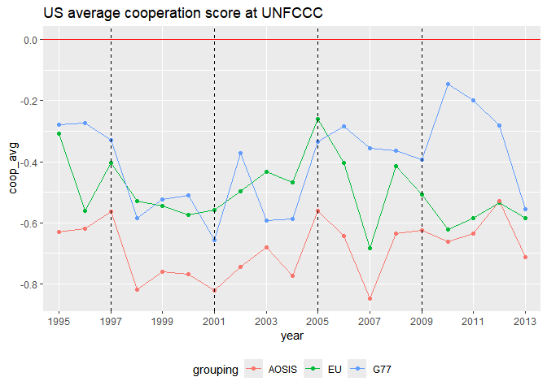

```r
bind_rows(useu, usg77, usaosis) %>% ggplot(aes(x=year, color = grouping)) +
  geom_line(aes(y = coop_avg)) + geom_hline(yintercept = 0, color = "red") +
  geom_point(aes(y = coop_avg)) +
  geom_vline(xintercept = c(1997, 2001, 2005, 2009), linetype = 'dashed') +
  scale_x_discrete(limits = c(1995, 1997, 1999, 2001,
                              2003, 2005, 2007, 2009, 2011, 2013)) +
  ggtitle("US average cooperation score at UNFCCC") +
  theme(legend.position = 'bottom')
```

```r
idneu <- calculate_coop("EU", "Indonesia", relationdb) %>% finish_coop_scores()
```

```
## argument.
## weighted_score_0, weighted_score_1, weighted_score_2)`
```

```r
idng77 <- calculate_coop("G77", "Indonesia", relationdb) %>% finish_coop_scores()
```

```
## argument.
## weighted_score_0, weighted_score_1, weighted_score_2)`
```

```r
idnaosis <- calculate_coop("AOSIS", "Indonesia", relationdb) %>% finish_coop_scores()
```

```
## weighted_score_0, weighted_score_1, weighted_score_2)`
```

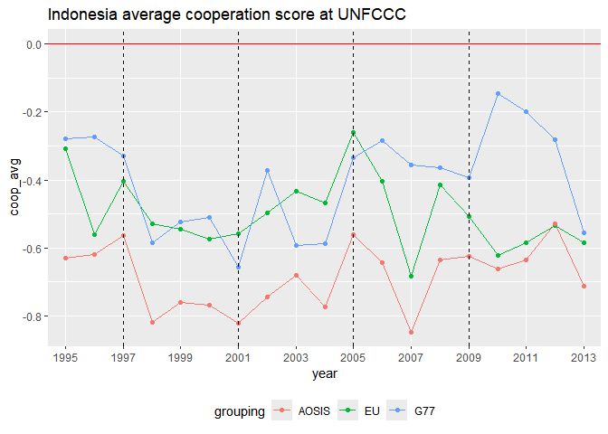

```r
bind_rows(useu, usg77, usaosis) %>% ggplot(aes(x=year, color = grouping)) +
  geom_line(aes(y = coop_avg)) + geom_hline(yintercept = 0, color = "red") +
  geom_point(aes(y = coop_avg)) +
  geom_vline(xintercept = c(1997, 2001, 2005, 2009), linetype = 'dashed') +
  scale_x_discrete(limits = c(1995, 1997, 1999, 2001,
                              2003, 2005, 2007, 2009, 2011, 2013)) +
  ggtitle("Indonesia average cooperation score at UNFCCC") +
  theme(legend.position = 'bottom')
```

# 2 Create index with PCA

(possible reference for improving figures: https://www.benjaminbell.co.uk/2018/02/principal-components-analysis-pca-in-r.html)

We will first compute the cooperation score for Brazil and all possible coalitions.

```r
coalitions <- c("AILAC", "ALBA", "AOSIS", "AfricanG", "ArabG", "BASIC", "COMIFAC", "CaribbeanC",
                "CentralAm", "CentralG11", "CfRN", "CongoB", "EITs", "EU", "EIG", "G77",
                "G9", #"CACAM",
                "LDCs", "LMDC", "Mountain", "OPEC", "SICA", "SAfricaDC",
                "Umbrella", "Visegrad"#, "AsianG"
                )

df <- map_df(coalitions, calculate_coop)
```

```
## argument.
## argument.
## argument.
## argument.
```

```r
df <- finish_coop_scores(df)
```

```
## weighted_score_0, weighted_score_1, weighted_score_2)`
```

```r
df <- select(df, -c(coop_score_0, coop_score_1, weighted_score_0, weighted_score_1,
                weighted_score_2, n_send, n_targ, state_total))
```

## 2.1 Main PCA - AOSIS, EU, G77, BASIC

For PCA, we need to first standardize the data. For this, we will work with Brazilian average cooperation score for AOSIS, EU, G77, and BASIC countries.

```r
df_num <- df %>%
  select(-c(weighted_score, weighted_score_avg, coop_score, coop_score_2)) %>% #calcular c/ coop_avg
  # filter(year == 1995) %>% # separar o ano (se nao quiser rodar PCA p/ todos dados juntos)
  pivot_wider(names_from = "grouping", values_from = "coop_avg") %>%
  select(-c(year, country)) %>% # remover as colunas não numéricas
  scale() %>% as_tibble() %>%
  select(AOSIS, EU, G77, BASIC)
```

For diagnostics, we can see the correlation matrix for each grouping:

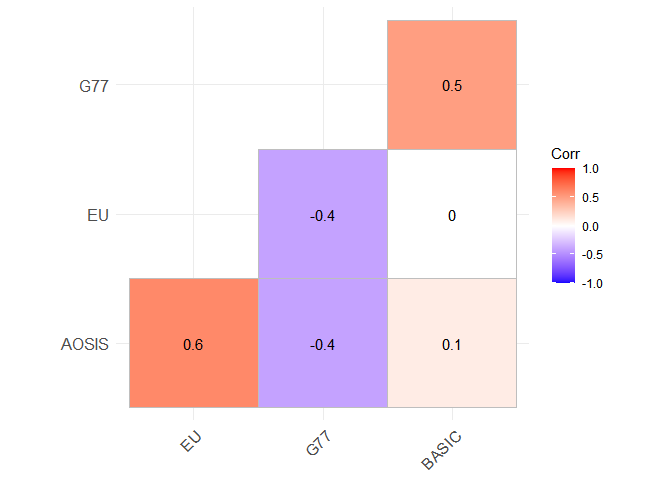

```r
df_num %>%
  cor(use="pairwise") %>% round(1) %>% ggcorrplot::ggcorrplot(type = 'lower',
                                                                      lab = T)
```

We can now compute principal components

```r
library(stats)
pca <- princomp(df_num, fix_sign = F)
#rev nao afeta resultado, é só por preferencia estetica na interpretaçao do eixo (na figura final)
```

```r
summary(pca, loadings = T, cutoff = 0.3)
```

```
## Importance of components:
##                           Comp.1    Comp.2     Comp.3     Comp.4
## Standard deviation     1.3902981 1.1188255 0.59729275 0.49801188
## Proportion of Variance 0.5100784 0.3303283 0.09414464 0.06544862
## Cumulative Proportion  0.5100784 0.8404067 0.93455138 1.00000000
##
## Loadings:
##       Comp.1 Comp.2 Comp.3 Comp.4
## AOSIS -0.569 -0.355  0.500 -0.547
## EU    -0.572        -0.762
## G77    0.561 -0.394 -0.344 -0.642
## BASIC        -0.796         0.530
```

### 2.1.1 Diagnostics

```r
library(factoextra)
get_eigenvalue(pca)
```

|  | eigenvalue | variance.percent | cumulative.variance.percent |
| --- | --- | --- | --- |
| Dim.1 | 1.9329287 | 51.007842 | 51.00784 |
| Dim.2 | 1.2517705 | 33.032832 | 84.04067 |
| Dim.3 | 0.3567586 | 9.414464 | 93.45514 |
| Dim.4 | 0.2480158 | 6.544862 | 100.00000 |

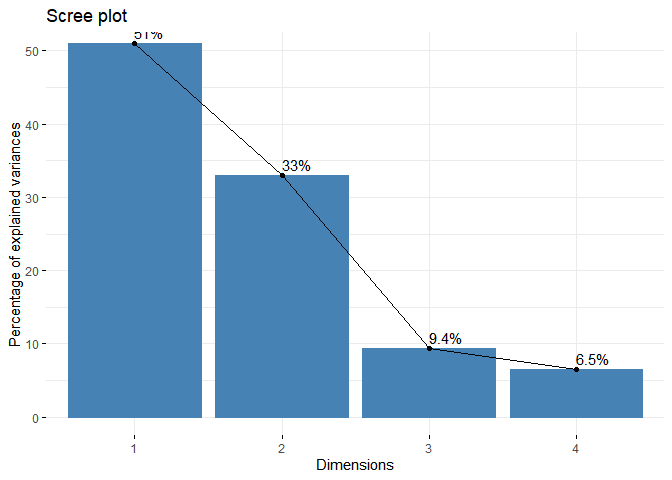

```r
fviz_eig(pca, addlabels = T, ylim = c(0, 50))
```

To interpret the dimensions more meaningfully, we can see that the 1st dimension is mainly driven by convergence with AOSIS/EU/G77, while the second dimension is mostly related to convergence with BASIC.

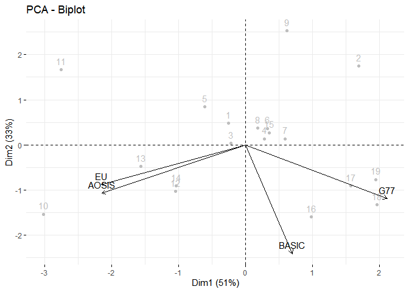

```r
fviz_pca_biplot(pca, repel = F, col.var = "black", col.ind = "gray")
```

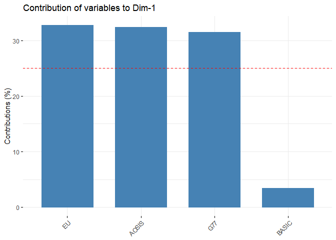

```r
fviz_contrib(pca, choice = "var", axes = 1, top = 10)
```

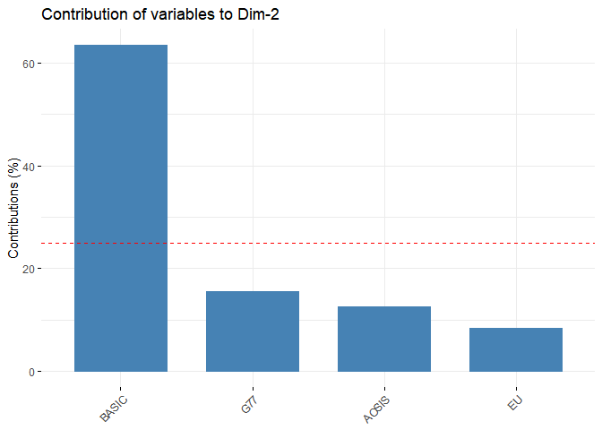

```r
fviz_contrib(pca, choice = "var", axes = 2, top = 10)
```

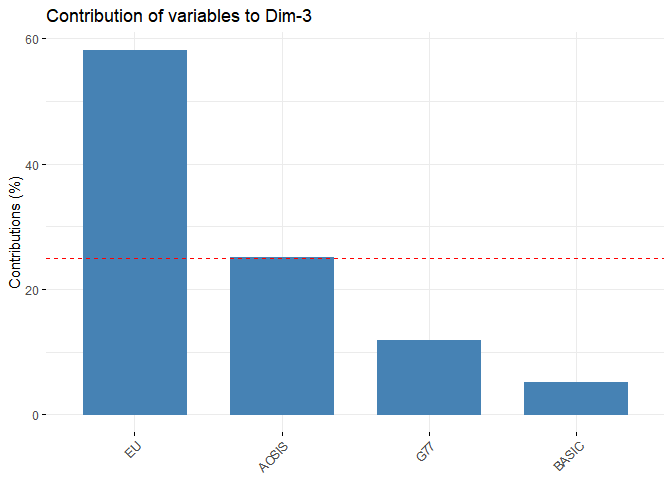

```r
fviz_contrib(pca, choice = "var", axes = 3, top = 10)
```